# Data about fEVAR numbers, patients and their aneurysms

Martin Hennessy

2024-02-06

# 1 Notes

- The terms fEVAR and FEVAR are considered to be the same.
- The terms fEVAR and FEVAR are sometimes used as a surrogate for all complex aneurysm repairs involving fenestrations, branches and thoracic endografts. In general, if the section refers to multiple types of complex aneurysm repair, fEVAR/FEVAR will tend to refer specifically to *fenestrated endografts only*, whereas if the section or graphic refers to all procedures, it is likely being used as a surrogate for *all complex repairs*.

# 2 Timeline of fEVAR in GG&C

- The first fEVAR was performed on 17 December 2009
- Since then 111 have been performed up until 26 January 2024
- However, the fEVAR performed before 10 March 2015 were offered ad hoc and only the remaining 104 are considered part of a formal fEVAR ‘service’
- For most graphics, these ad hoc fEVAR will be included

## 2.1 fEVAR and EVAR numbers over time

- The number of infra-renal elective EVAR and all fEVAR per year since the first fEVAR was performed are shown below:

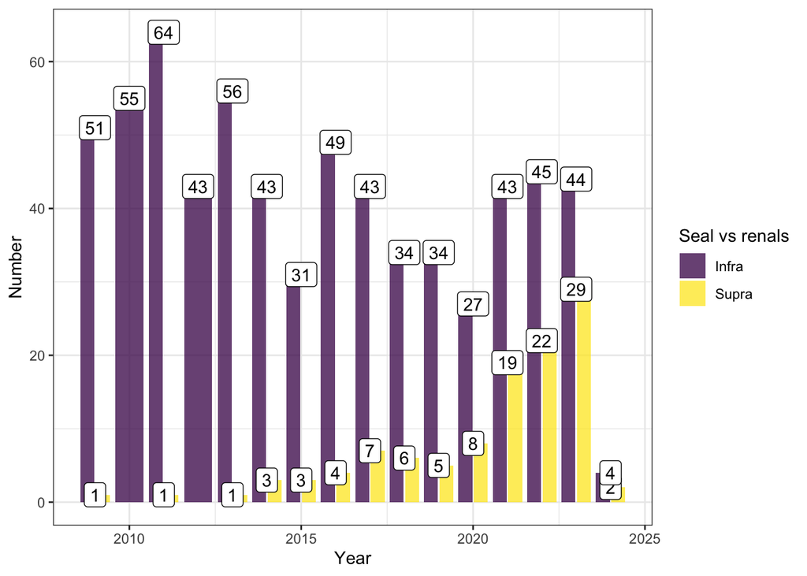

## 2.2 fEVAR numbers over time

- The number of fEVAR per year since the first fEVAR was performed are shown below:

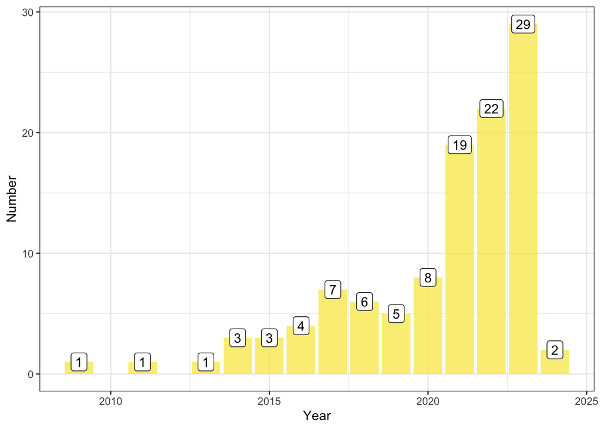

## 2.3 fEVAR device over time

- Choice of stent-graft has changed over time, as shown below:

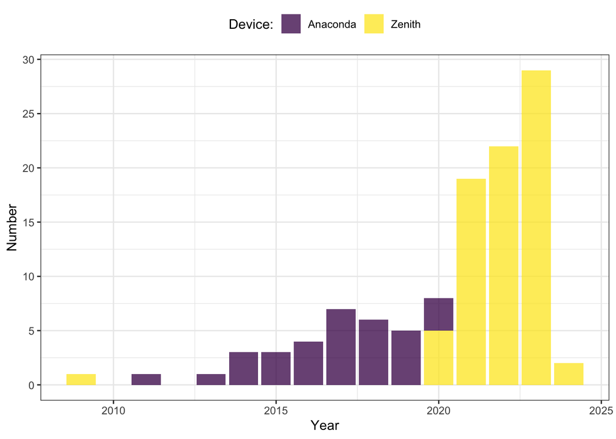

- Total numbers of each stent-graft used are shown here:

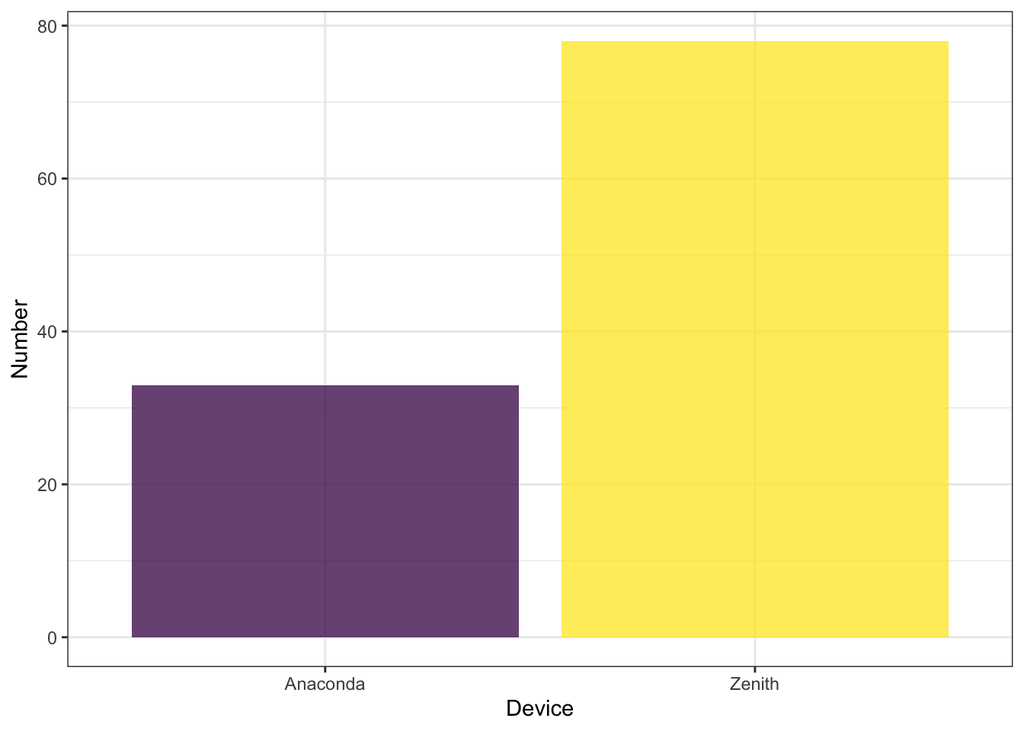

# 3 Sex, age and healthboard of patients undergoing fEVAR in GG&C

## 3.1 Sex

- Split between men and women, the numbers of fEVAR are as follows:

| **Characteristic** | **N = 111**<sup>1</sup> |
| --- | --- |
| Sex |  |
| Man | 92 (83%) |
| Woman | 19 (17%) |

<sup>1</sup> n (%)

- Further breaking down the men into those whose aneurysm was discovered by the national aneurysm screening programme:

| **Characteristic** | **N = 111**<sup>1</sup> |
| --- | --- |
| Detection state: |  |
| Non-screened man | 68 (61%) |
| Screened man | 24 (22%) |
| Woman | 19 (17%) |

<sup>1</sup> n (%)

- Since 2012, men in Scotland have been invited to attend in the year of their 65th birthday for an ultrasound to detect AAA.
- If the aneurysm was detected by the screening programme, both those who had an aneurysm of treatment size at first screen and those who had an aneurysm below treatment size which subsequently grew to treatment size are included in the ‘screened’ category.

## 3.2 Age

- Patient ages varies from 60 to 86 years old with the distribution shown on the following histogram:

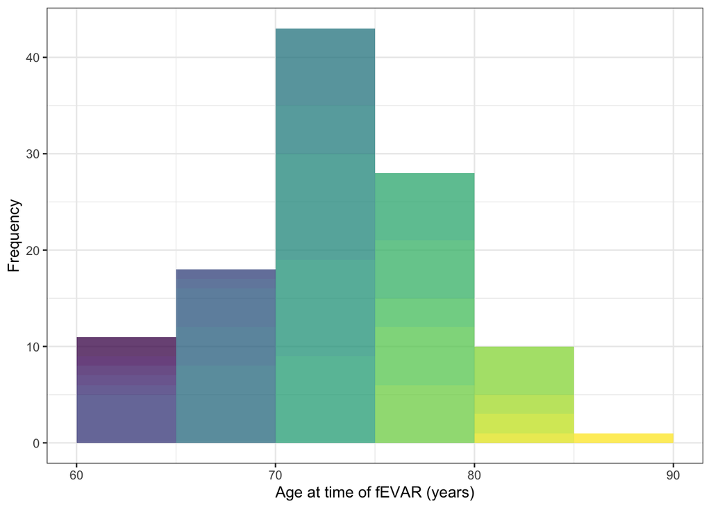

- These data look normally distributed but this can be tested by Shapiro Wilk normality test with the null hypothesis that the age data are normally distributed: *p* = 0.27.
- Data are therefore best summarised with mean and standard deviation:

| **Characteristic** | **N = 111**<sup>1</sup> |
| --- | --- |
| Age | 73.6 (5.4) |

<sup>1</sup> Mean (SD)

- To assess for any difference between men and women, first we should check the age for both groups is evenly distributed:

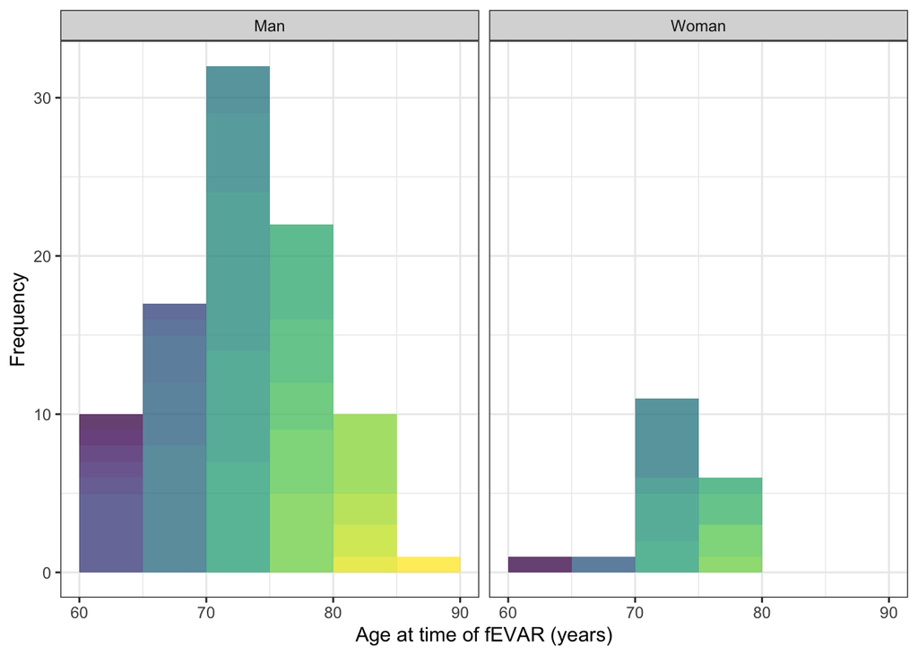

- As these are both evenly distributed they can be compared with a t test:

| **Characteristic** | **Man**, N = 92<sup>1</sup> | **Woman**, N = 19<sup>1</sup> | **p-value**<sup>2</sup> |
| --- | --- | --- | --- |
| Age | 73.6 (5.6) | 73.5 (4.6) | 0.9 |

<sup>1</sup> Mean (SD)  
<sup>2</sup> Welch Two Sample t-test

- There is no statistical difference.
- Finally, we can assess for any difference between screened men, non-screened men and women, first checking the age for both groups is evenly distributed:

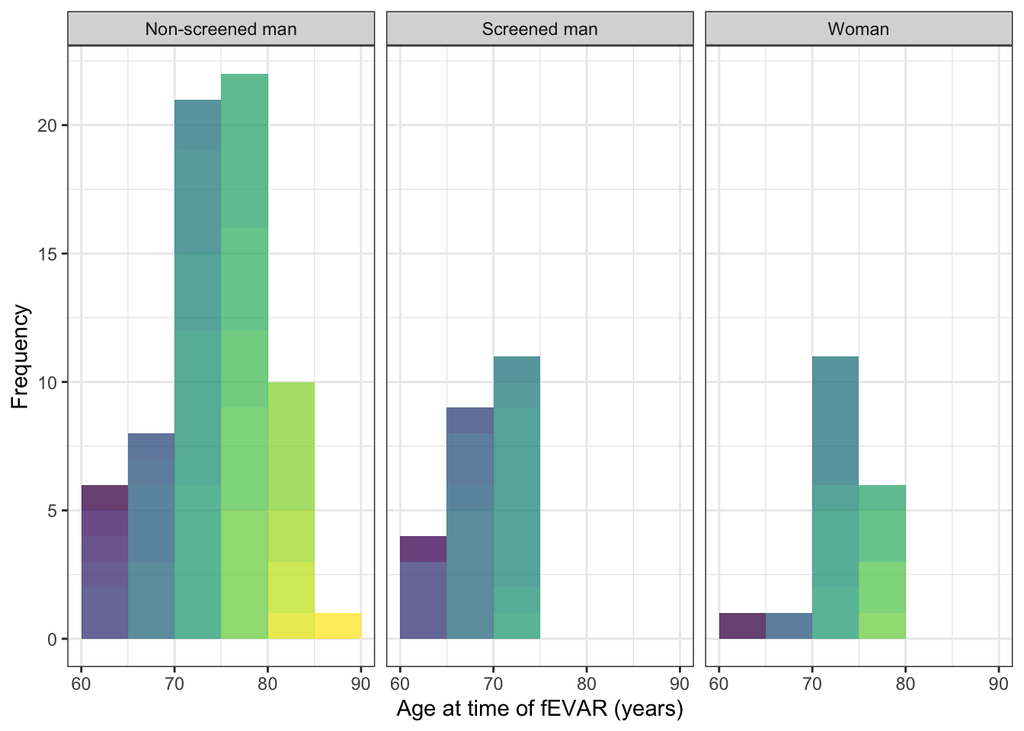

- Screened men clearly have an abnormally distributed age and so ages should be compared with a Kruskall-Wallis test:

| **Characteristic** | **Non-screened man**, N = 68<sup>1</sup> | **Screened man**, N = 24<sup>1</sup> | **Woman**, N = 19<sup>1</sup> | **p-value**<sup>2</sup> |
| --- | --- | --- | --- | --- |
| Age | 75.0 (72.0, 79.0) | 70.0 (68.0, 73.0) | 74.0 (71.0, 76.5) | <0.001 |

<sup>1</sup> Median (IQR)  
<sup>2</sup> Kruskal-Wallis rank sum test

- There is a statistical difference between the ages.

## 3.3 Health Board

- Not all fEVAR are for Greater Glasgow & Clyde health board patients.
- Since 2019, Greater Glasgow & Clyde health board has taken over the vascular services of Forth Valley health board.
- The patient’s health board are shown on the following column chart:

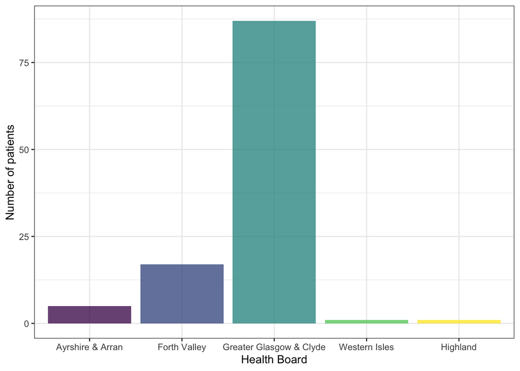

## 3.4 Size

- Treated aneurysm size varies from 40 mm (in a patient with a common iliac artery at treatment threshold and AAA below treatment threshold) to 100 mm, as shown on the following histogram:

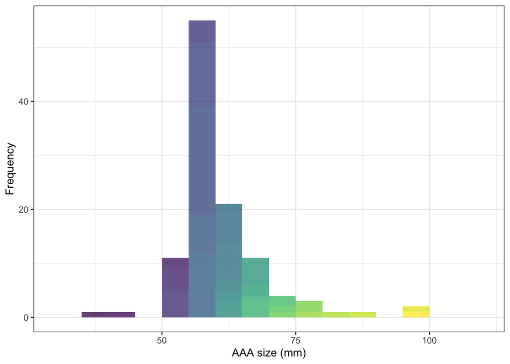

- Shapiro Wilk normality test with the null hypothesis that the age data are normally distributed: *p* = 0 (ie. they are abnormally distributed)
- Data are therefore best summarised with median and interquartile range:

| **Characteristic** | **N = 111**<sup>1</sup> |
| --- | --- |
| AAA size (mm) | 59 (57, 63) |

<sup>1</sup> Median (IQR)

- As we have previously seen that screened men are treated younger than non-screened men, we can quickly assess if the same holds true for the size of their (and women’s) aneurysms:

| **Characteristic** | **Non-screened man**, N = 68<sup>1</sup> | **Screened man**, N = 24<sup>1</sup> | **Woman**, N = 19<sup>1</sup> | **p-value**<sup>2</sup> |
| --- | --- | --- | --- | --- |
| AAA size (mm) | 60 (57, 65) | 59 (58, 61) | 60 (58, 62) | 0.7 |

<sup>1</sup> Median (IQR)  
<sup>2</sup> Kruskal-Wallis rank sum test

- There is no significant difference in aneurysm size.